# Statistical Inference Course Project 1

RossAW

27 September 2015

## Overview

This project consists of two parts, a simulation exercise and a basic inferential data analysis.

```r
library(ggplot2)
```

# Simulations

### The Exponential Distribution

Lets have a look at what that looks like.

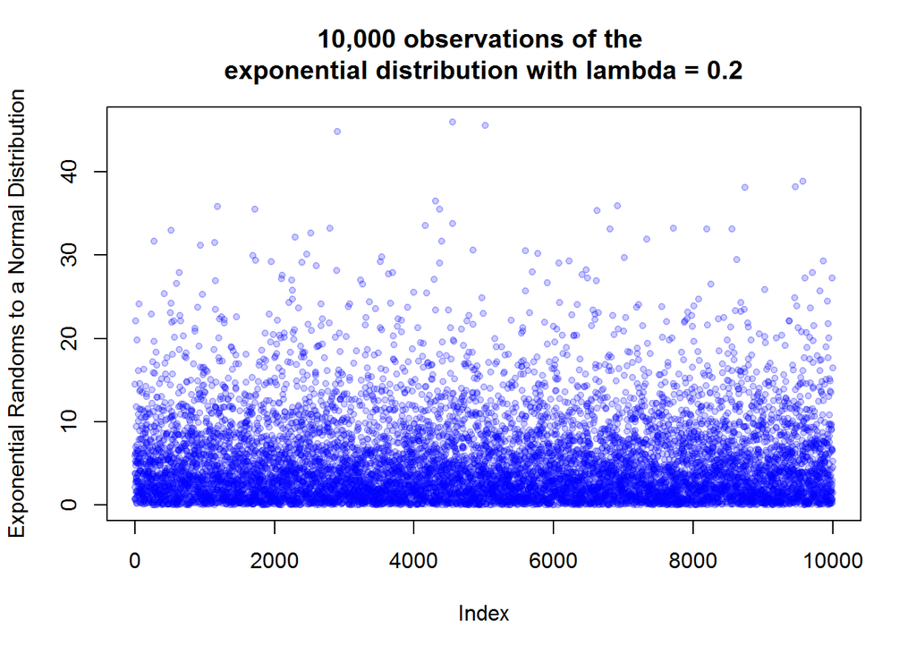

```r
set.seed(1)
lambda <- 0.2

NumberOfSims <- 10000

exponentialRandoms<-rexp(NumberOfSims,lambda)

plot(exponentialRandoms, pch=20, col=rgb(0,0,1,0.2), main = "10,000 observations of the \nexponential distribution with lambda = 0.2", ylab= "Exponential Randoms to a Normal Distribution")
```

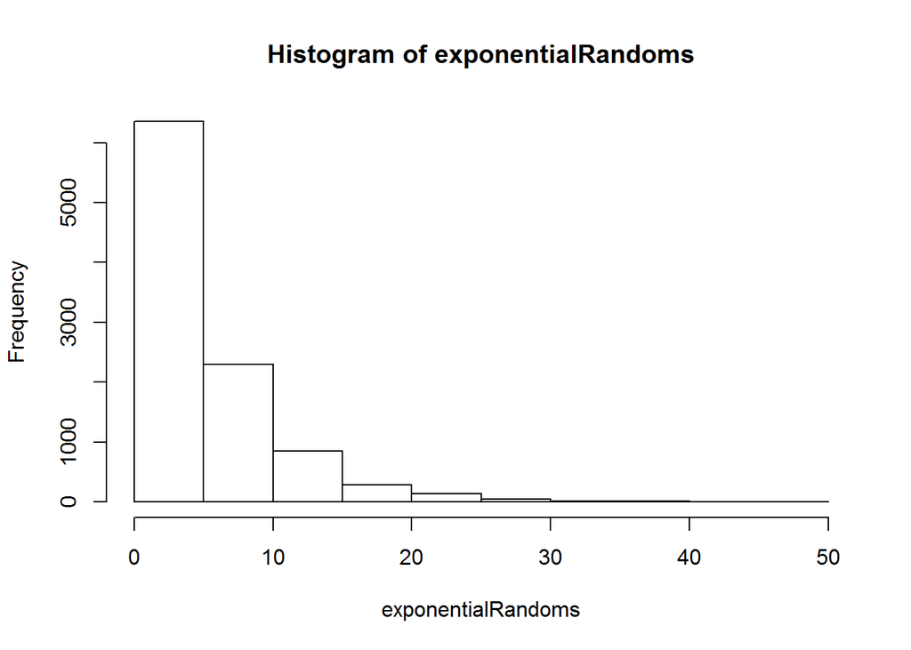

```r
hist(exponentialRandoms)
```

To answer the remaining questions we need to take the average of 40 random exponentials, 1000 times. This will give us 1000 averages of exponential Randoms.

```r
n <- 40 # Average of n random exponentials
AveragOfExponentialRandoms<-NULL

for(i in 1:1000){

    AveragOfExponentialRandoms=c(AveragOfExponentialRandoms,mean(rexp(n,0.2)))
}
```

### Sample Mean vs Theoretical Mean

This compares the mean of the sample means to the theoretical mean.

```r
TheoreticalMean<-1/lambda
TheoreticalMean
```

```
## [1] 5
```

```r
SampleMean<-mean(AveragOfExponentialRandoms)
SampleMean
```

```
## [1] 5.025866
```

As predicted by the CLT the mean of the sample means is near identical to the population mean.

### Sample Variance vs Theoretical Variance

This compares the sample varianace to the theoretical variance.

```r
SampleVariance<-var(AveragOfExponentialRandoms)
SampleVariance
```

```
## [1] 0.6374065
```

```r
TheoreticalVariance<-(1/lambda^2)/n
TheoreticalVariance
```

```
## [1] 0.625
```

As predicted by the CLT the sample varaiance is near identical to the population variance.

### Distribution vs Normal Distribution

The CLT states that the average of a set of random samples is approximately Normally distributed with a mean given by the propluation mean and a variance given by the standard error of the mean N(mu,sig^2/n)

[figure not shown]

```r
AveragOfExponentialRandoms<-data.frame(AveragOfExponentialRandoms)
TheoreticalSD<-sqrt(TheoreticalVariance)

g <- ggplot(AveragOfExponentialRandoms, aes(x = AveragOfExponentialRandoms)) + geom_histogram(binwidth=.3, colour = "black", aes(y = ..density..))
g <- g + stat_function(fun = dnorm, size = 2,colour="blue",args = list(mean = TheoreticalMean, sd = TheoreticalSD))
g<-g+ylab("Number of Injuries")+
        xlab("Type of Weather Event")+
        theme(axis.text.x = element_text(angle = 45,hjust = 1))+
        ggtitle("Comparing the Count of Random Exponential Averages \n with the Normal distribution")
g
```

The above graph shows that the distribution is very well described by the normal distribution.